# Logistic regression

brouwern@gmail.com

December 2, 2016

# Logistic regression

** Regression with “binary data” **

## What kinds of things are “Binary”

- **0 / 1**
- **either / or**
- **yes / no**
- **alive / dead**
- **sick / healthy**
- **flowered / didn’t flower**
- **eaten by deer / not eaten by deer**
- **caught something in trap / didn’t catch something**
- **shot a deer/didn’t shoot a deer**

In R, you can have binary data coded as 0s and 1s, or two categorical variables, “alive” vs. “dead”.

## Two types of binary data

Depending on how a study was conducted or how an experiemnt carried out, binary data usually gets colelcted in one of two ways.

### Binary data type 1:

#### (# of “events”)/(# of “trials”)

Often, a fixed number of things were observed, and a certain number of times something happend. This data is in the form (# of “events”)/(# of “trials”)

- (# of seeds germinated) / (# of seeds planted)
- (# of dead tadpoles) / (# exposed to pesticide)
- (# of eaten plants) / (# of plants in forest)
- (# of deer shot) / (# of hunters in forest)

#### Requires that the **denominator** is known

#### These data are usually easily aggregated in a table

#### Often used when you have a *categorical* predictor

#### Often used for experiments that generate binary data

#### Comments:

In each case a denominator, the number of trials, can be defined, and the number of events counted. It can be tempting to just use the counts, but including the number of trials is important.

A **major assumption** of the models used to analyze binary data is that **each and every trial** and **each and every event that happens** are independent. Ideally, this means they take place in a seperate, isolated location and what happens in one trial does not impact the other trials. So, if you are looking at seed germination, ideally you would germinate each seed in a seperate pot. If you germinate all of your seeds in a single pot, they are not indepednent. If you are assesing the toxicity of a pesticide on an insect, each insect would be exposed to the chemical in a seperate trial. If all of your insects are housed in a single container and are all sprayed at the same time, they are not indepenent.

Several people in class have this kind of data. In some cases their trials are independent; in others, they are not.

### Binary data type 2:

#### Did an event happen? ~ predictor variable

- Did you shoot a deer? ~ distance from forest edge
- Did the Trillium flower? ~ size of the plant
- Was the Trillium eaten? ~ number of deer in forest
- Did the person get the flu? ~ concentration of vaccine given

These data are usually hard to aggregate because each “trial”" (a plant that might flower, or that might be eaten) is associated with a unique predictor variable (size of the plant)

A few people in class might have this kind of data. Shows up often in field studies.

## Binary data Example 1: (# of “events”)/(# of “trials”)

### Experiment: effect of cold exposure on fish

Whitlock & Shulter logistic regression example page 568

```r
## Load data from page 568

### Original data has a sample size of 40
df1.n40 <- data.frame(died.YN = c(11,24,29,38),
                  lived.YN = c(29,16,11,2),
                  exposure.min = c(3,8,12,18))

df1.n40$total.fish <- df1.n40$died.YN +df1.n40$lived.YN

#reduce same size to 20
#make change to data for illustration purposes
df1.n20 <- df1.n40
df1.n20$died.YN <- round(df1.n20$died.YN/2,0)
df1.n20$lived.YN <- round(df1.n20$lived.YN/2,0)
df1.n20$total.fish <- df1.n20$died.YN +df1.n20$lived.YN
```

### Look at dataframe

```r
df1.n20
```

```
##   died.YN lived.YN exposure.min total.fish
## 1       6       14            3         20
## 2      12        8            8         20
## 3      14        6           12         20
## 4      19        1           18         20
```

## Common way to think about binary data: percentages

- Binary data often converted to percentage
- Divide # of events by # of trials
- This can cause problems

Calculate perentage mortality for fish data

```r
percent.died <- df1.n20$died.YN/df1.n20$total.fish

df1.n20 <- cbind(percent.died, df1.n20)
```

Look at new percentage data

```r
df1.n20
```

```
##   percent.died died.YN lived.YN exposure.min total.fish
## 1         0.30       6       14            3         20
## 2         0.60      12        8            8         20
## 3         0.70      14        6           12         20
## 4         0.95      19        1           18         20
```

## The problem with percentages from binary data

### Problem 1: they hid the sample size

- What if I said “50% of people who stand in front of a microrwave while warming up their coffee get cancer, and I have data to prove it.”
- What would be a key feature of this study? … Sample size!
- What if my data had n = 2? (1 got cancer)
- What if my data had n = 100? (50 got cancer)
- Both data have caner rate = 50%
- Which dataset is more reliable?

### Problem 2: people who use them often incorrectly calcualte confidence intervals (CIs)

#### Model percent.died vs. exposure to cold

Use standard regression w/ lm()

```r
lm.percent <- lm(percent.died ~ exposure.min,
                 data = df1.n20)
```

#### Look at model output

Use summary(…)

```r
summary(lm.percent)
```

```
##
## Call:
## lm(formula = percent.died ~ exposure.min, data = df1.n20)
##
## Residuals:
##        1        2        3        4
## -0.03354  0.05683 -0.01087 -0.01242
##
## Coefficients:
##              Estimate Std. Error t value Pr(>|t|)
## (Intercept)  0.207764   0.050907   4.081   0.0551 .
## exposure.min 0.041925   0.004377   9.578   0.0107 *
## ---
## Signif. codes:  0 '***' 0.001 '**' 0.01 '*' 0.05 '.' 0.1 ' ' 1
##
## Residual standard error: 0.0481 on 2 degrees of freedom
## Multiple R-squared:  0.9787, Adjusted R-squared:  0.968
## F-statistic: 91.74 on 1 and 2 DF,  p-value: 0.01073
```

- As exposure time increase, the percentage of fish that die increases.
- What number tells you this?

#### Plot the data

```r
newdat <- data.frame(exposure.min = 3:20)
ci.out <- predict(lm.percent,
                  interval = "confidence",
                  newdata = newdat)
```

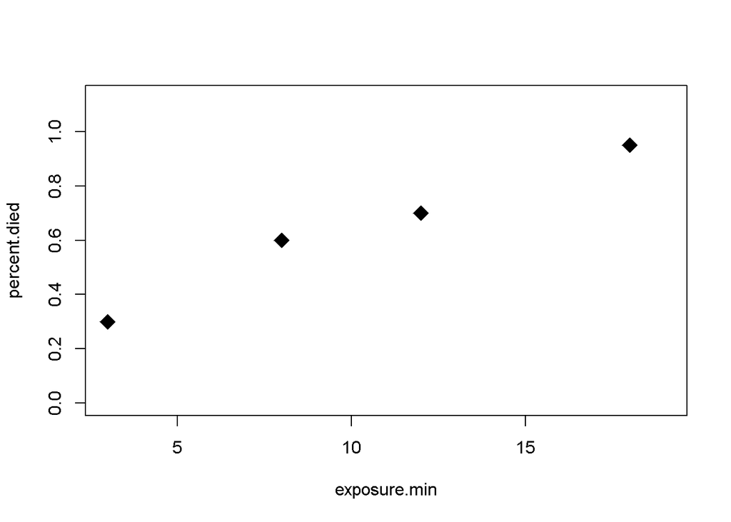

```r
par(mfrow = c(1,1))
plot(percent.died ~ exposure.min, data = df1.n20,
     pch = 18, cex = 2,
     xlim = c(3, 19),
     ylim = c(0,1.125))
```

Ok, as exposure to cold increases, mortality increase

#### Plot the percentage data w/ the regression line

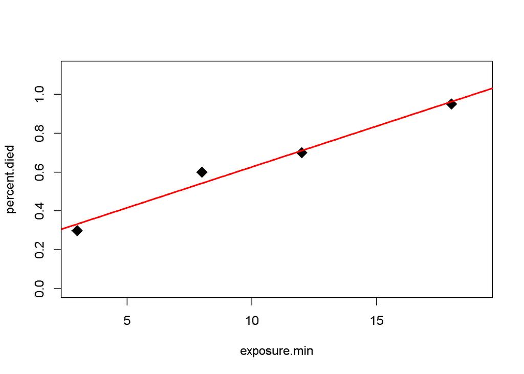

```r
par(mfrow = c(1,1))
plot(percent.died ~ exposure.min, data = df1.n20,
     pch = 18, cex = 2,
     xlim = c(3, 19),
     ylim = c(0,1.125))
abline(lm.percent, col = 2, lwd = 2)
```

Nice regression line showing trend

#### Plot the data w/regression line & 95% CI

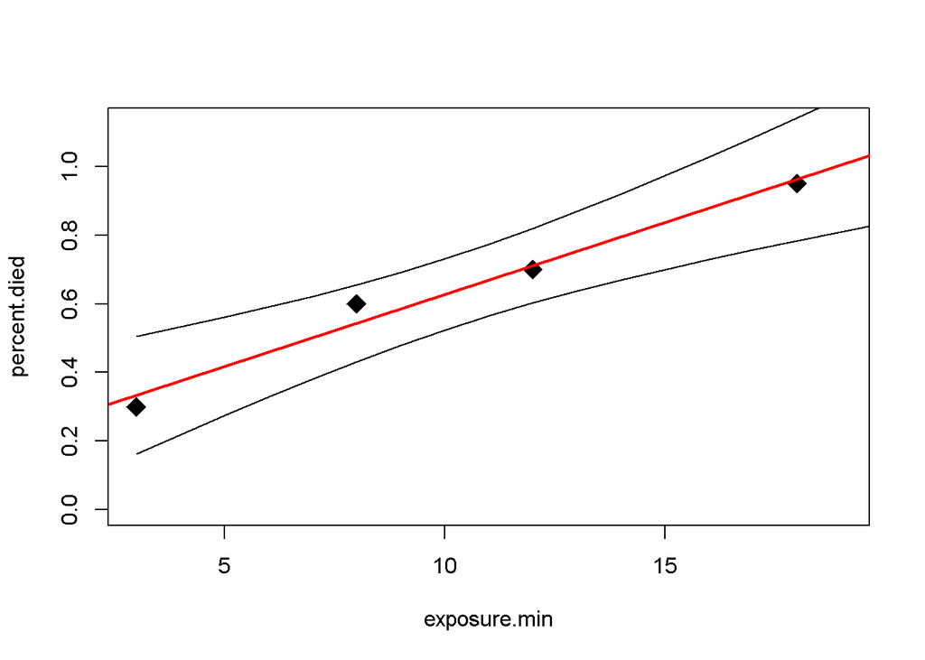

```r
par(mfrow = c(1,1))
plot(percent.died ~ exposure.min, data = df1.n20,
     pch = 18, cex = 2,
     xlim = c(3, 19),
     ylim = c(0,1.125))
abline(lm.percent, col = 2, lwd = 2)
points(ci.out[,"lwr"] ~ newdat$exposure.min,
       type = "l")
points(ci.out[,"upr"] ~ newdat$exposure.min, type = "l")
```

Fancy confidnece interval around trend. Nice, but…

#### Plot the data w/regression line, 95% CI, and refernece line for percent.died = 1

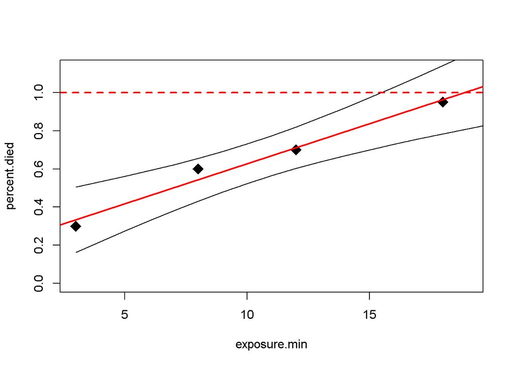

```r
plot(percent.died ~ exposure.min, data = df1.n20,
     pch = 18, cex = 2,
     xlim = c(3, 19),
     ylim = c(0,1.125))
abline(lm.percent, col = 2, lwd = 2)
points(ci.out[,"lwr"] ~ newdat$exposure.min,
       type = "l")
points(ci.out[,"upr"] ~ newdat$exposure.min, type = "l")
abline(h = 1, col = 2, lwd = 2, lty = 2)
```

- What does it mean the the confidence interval crosses 1.0?
- Subtle point: if your model can make confidence intervals for data points that don’t make sense, something is wrong with the model!

## Correct analysis of binary data

### A correct analysis uses a model that

#### 1)Includes information on the sample size

#### 2)Properly models the binary nature of the data

#### This requires “logistic regression”

#### This is a type of “generalized linear model”

## Coding a logistic regression GLM

- **uses R’s glm() function**
- **requires a statement of the “family” of the model**
- **here family = “binomial”**
- **Also need to indicate sample size (n)**
- **use “weights =” argument**
- **here, weights = total.fish**

## Code to run the logistic regression model model

```r
glm1 <- glm(percent.died ~ exposure.min,
            data = df1.n20,

            #model family:
            family = "binomial",

            #sample size
            weights = total.fish)
```

#### Logistic regression GLM output

Use summary() command just as for regular regression

```r
summary(glm1)
```

```
##
## Call:
## glm(formula = percent.died ~ exposure.min, family = "binomial",
##     data = df1.n20, weights = total.fish)
##
## Deviance Residuals:
##        1         2         3         4
##  0.01735   0.30995  -0.62850   0.45772
##
## Coefficients:
##              Estimate Std. Error z value Pr(>|z|)
## (Intercept)   -1.5280     0.5613  -2.722 0.006479 **
## exposure.min   0.2241     0.0579   3.870 0.000109 ***
## ---
## Signif. codes:  0 '***' 0.001 '**' 0.01 '*' 0.05 '.' 0.1 ' ' 1
##
## (Dispersion parameter for binomial family taken to be 1)
##
##     Null deviance: 21.04467  on 3  degrees of freedom
## Residual deviance:  0.70089  on 2  degrees of freedom
## AIC: 16.691
##
## Number of Fisher Scoring iterations: 4
```

- This looks almost the sames as for regular regression
- BUT - the “slope” parameter for a GLM only tells you the overall direction of a trend (positive or negative)
- The slope is on a special “logistic regression” scale

#### Plot output of model

- Logistic regression output is on a special scale
- Why this is is beyond this class: it has to do with logs :(
- R’s “predict” function converts from this “special” to a percentage/probability scale
- This special scale is called the “link” scale
- The normal scale we can interpret is the “response” scale
- That is, the scale that the original response variable was measured on

Get predictions from our GLM

```r
#Predictions from GLM
newdat <- data.frame(exposure.min = 3:20)
se.outlink <- predict(glm1,
                  se.fit = T,
                  type = "link",
                  newdata = newdat)

library(arm)
glm.cis <- data.frame(predictions = invlogit(se.outlink$fit),
                      lwr = invlogit(se.outlink$fit - 1.96*se.outlink$se.fit),
                      upr = invlogit(se.outlink$fit + 1.96*se.outlink$se.fit))

glm.cis <- cbind(glm.cis,newdat)
```

#### Plot the output of the GLM:

##### Data w/regression line

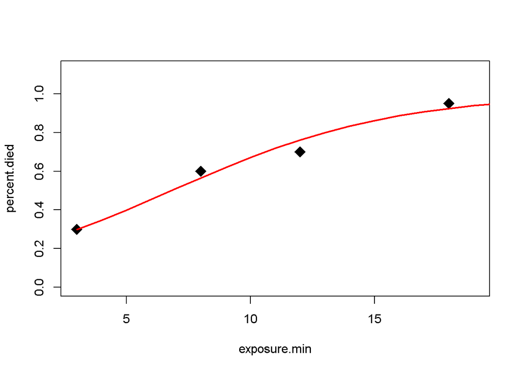

```r
plot(percent.died ~ exposure.min, data = df1.n20,
     pch = 18, cex = 2,
     xlim = c(3, 19),
     ylim = c(0,1.125))
points(predictions ~ exposure.min,
       type = "l", data  = glm.cis, col = 2, lwd = 2)
```

#### Plot the output of the GLM:

##### Data, line, confidence intervals

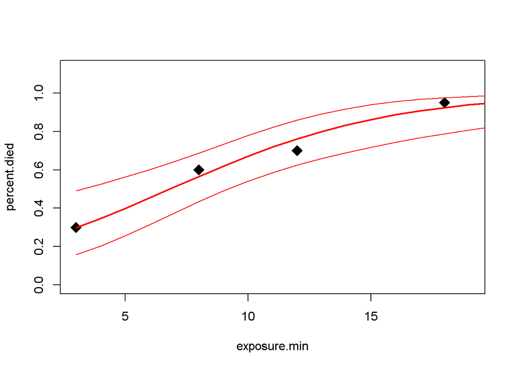

```r
plot(percent.died ~ exposure.min, data = df1.n20,
     pch = 18, cex = 2,
     xlim = c(3, 19),
     ylim = c(0,1.125))
points(predictions ~ exposure.min,
       type = "l", data  = glm.cis, col = 2, lwd = 2)
points(upr ~ exposure.min,
       type = "l", data  = glm.cis, col = 2)
points(lwr ~ exposure.min,
       type = "l", data  = glm.cis, col = 2)
```

#### Plot the output of the GLM:

##### Data, line, CIs, and reference line at 1.0

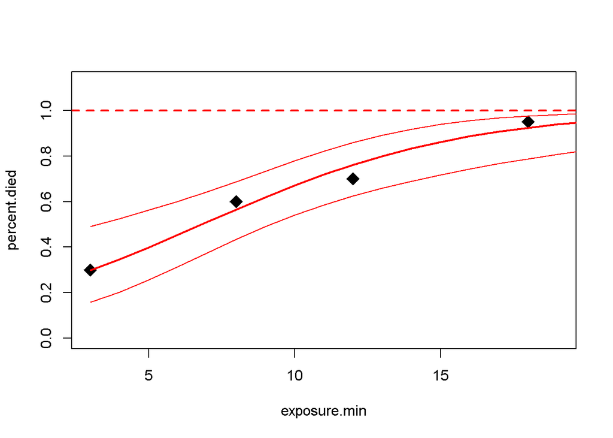

```r
plot(percent.died ~ exposure.min, data = df1.n20,
     pch = 18, cex = 2,
     xlim = c(3, 19),
     ylim = c(0,1.125))
points(predictions ~ exposure.min,
       type = "l", data  = glm.cis, col = 2, lwd = 2)
points(upr ~ exposure.min,
       type = "l", data  = glm.cis, col = 2)
points(lwr ~ exposure.min,
       type = "l", data  = glm.cis, col = 2)

abline(h = 1, col = 2, lwd = 2, lty = 2)
```

### Fish survival ~ fish size

Make up some data

```r
size <- seq(10,100,length.out = 50)
died.YN <- c(1,1,1,1,1,1,1,1,1,1,1,1,
             1,0,1,1,1,0,0,1,0,1,0,1,
             1,1,0,0,0,0,1,0,0,0,1,0,
             1,0,0,1,0,0,0,0,0,1,0,0,
             0,0)

df3 <- data.frame(died.YN = died.YN,
                  size = size)
```

#### Plot data

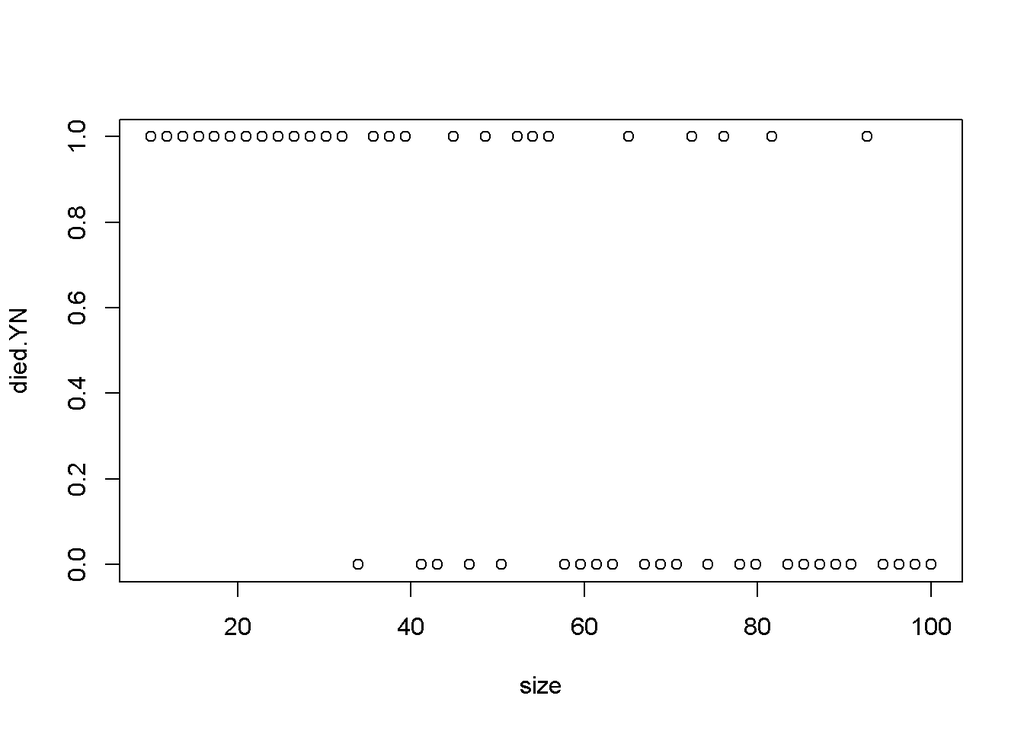

```r
plot(died.YN ~ size, data = df3)
```

#### Model data

- Model with glm()
- family = binomial
- DO NOT put anything in for sample size
- that is, don’t use anything for weight arguement

```r
glm2 <- glm(died.YN ~ size, data = df3,

            # family of modle
            family = "binomial")
```

```r
summary(glm2)
```

```
##
## Call:
## glm(formula = died.YN ~ size, family = "binomial", data = df3)
##
## Deviance Residuals:
##     Min       1Q   Median       3Q      Max
## -1.8127  -0.7531   0.3369   0.6730   2.1434
##
## Coefficients:
##             Estimate Std. Error z value Pr(>|z|)
## (Intercept)  3.51383    1.01460   3.463 0.000534 ***
## size        -0.06157    0.01685  -3.655 0.000257 ***
## ---
## Signif. codes:  0 '***' 0.001 '**' 0.01 '*' 0.05 '.' 0.1 ' ' 1
##
## (Dispersion parameter for binomial family taken to be 1)
##
##     Null deviance: 69.235  on 49  degrees of freedom
## Residual deviance: 48.266  on 48  degrees of freedom
## AIC: 52.266
##
## Number of Fisher Scoring iterations: 4
```

- The negative value means that as fish get bigger, the probablity that they die **decreases**
- As before, these numbers that come from glm() cannot be directly interpretted
- We can interpret the p-value for the slope as we normally would

### Plot with regression line

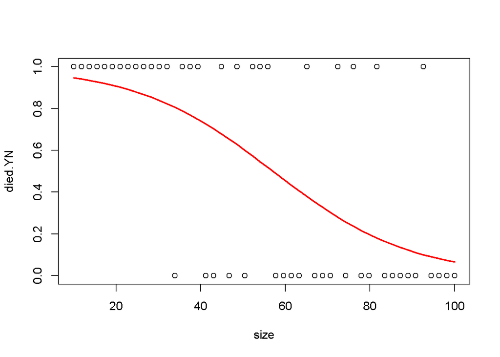

```r
predictions <- predict(glm2,type = "response")
plot(died.YN ~ size, data = df3)
lines(predictions ~ df3$size, type = "l", col = 2, lwd = 2)
```